# EXPLORATORY DATA ANALYSIS ON Programmers Survey

### PROBLEM STATEMENT:

The Goal of this Project is to analyze the Stack overflow Developer Survey data to understand developer demographics, employment, patterns and work trends using exploratory data analysis(EDA).

### Project Flow Section

1.Data loading and cleaning  
2.Exploratory data analysis  
3.Visualization of key patterns  
4.Insights and conclusions

### Why This Analysis Need:

Understanding developer demographics, employment patterns, and work habits to help organizations to better analysis.  
Design better hiring strategies and improve developer work-life balance and generated Analysis on this Dataset.

## SUMMARY

This Project analyzes the Stack Overflow Developer Survey dataset to understand global developer demographics,employment,patterns,education backgrounds,and work habits. Using Python,Pandas,Numpy,Matplotlib&Seaborn and key insights were extracted through exploratory data analysis and visualization.

### STEP-1.SELECT A REAL-WORLD DATASET

*Find and download an interesting real-world dataset from Internet KAGGLE(Recommended). *The dataset should contain tabular data (rows&columns),Prefer in CSV,JSON,XLS or other formats that can read using pandas. *If its not compatible format, you may have to write some code to convert it to desired formart. *The dataset should contain at least 3 columns and 150 rows of data. This is minimum dataset to show case the formulas exploration.

### STEP-2.PERFORM DATA PREPARATION & CLEANING

*Load the dataset into a data frame using Pandas.*Explore the total number of rows & columns,ranges of values etc. *Handle missing, incorrect and invalid data from the dataset. *Perform any additional steps if needed (like creating additonal columns for the dataset, merging dataset etc).

### STEP-3.PERFORM EXPLORATORY ANALYSIS & VISUALIZATION

*Compute the mean,sum,range and other intresting statistics for numeric columns.*Explore distributions of numeric columns using histograms.*Explore relationship between columns using bar charts, scatter plots. *Make a note of interesting insights from the exploratory analysis.

### STEP-4.ASK & ANSWER QUESTIONS ABOUT THE DATA

*Ask at least 5 interesting questions about your dataset.* Answer the questions either by computing the results using Numpy/Pandas or by Plotting graphs using Matplotlib/Seaborn.*create new coloumns,merge mulitple dataset and perform grouping/aggregation wherever necessary.***Mainly wherever you are using library functions from Pandas/Numpy/Matplotlib/Seaborn first import them correctly then use it.

### STEP-5.SUMMARIZE YOUR INFERENECES & WRITE A CONCLUSION

*Write a summary of what you learned from the analysis,inlcuding interesting insights and graphs from your notebook make to SAVE IT to share with other people.

### STEP-6.SHARE TO GITHUB REPOSITORY TO STORE YOUR INFO OF YOUR COMPLETE PROJECT

DATASETS :  
1.Kaggledataset(https://www.kaggle.com/datasets) (Recommended)  
2.UCI Machine Learning Repositroy(https://archive.ics.uci.edu/)  
3.awesome-public-datasets(https://github.com/awesomedata/awesome-public-datasets?files=1)  
4.Google Dataset Search(https://datasetsearch.research.google.com/)

# PROJECT TITLE

For this Specific Project firstly i used to download the dataset from the kaggle site directly to my PC downloads and from their it self i extracted this file Because it is having huge dataset.

Import OS to see the file is existing or not in the right location - to read the file give the syntax as {os.listdir(r"file path")}

```python
import os
```

```python
os.listdir(r"C:\Users\munik\Downloads\archive (16)\Project_File_NPMS")
```

```
['.ipynb_checkpoints',
 'README_2020.txt',
 'survey_results_public.csv',
 'survey_results_schema.csv']
```

README.txt -> Containing information about the dataset

survey_results_public.csv -> The full list of responses to the questions

survey_results_schema.csv -> Containing the list of questions(short codes for each question)

Mainly we have to calculate the dataset with the libraries like [pandas,Numpy,Matplotlib,Seaborn] PANDAS is for Organizing data into rows and columns making it (easy to clean, analyze, and manipulate). NUMPY is for Numerical computing and working with large datasets for (mathematical operations,statistical operations). MATPLOTLIB is creating static, animated and interactive (data visualizations). SEABORN is also for (data visualizations).

If you need PANDAS you need to import->(import pandas as pd) NUMPY importing ->(import numpy as np) MATPLOTLIB importing ->(import matplotlib.pyplot as plt) SEABORN importing -> (import seaborn as sns)

```python
import pandas as pd
```

```python
survey_raw_df = pd.read_csv(r"C:\Users\munik\Downloads\archive (16)\Project_File_NPMS/survey_results_public.csv")
```

```python
survey_raw_df
```

|  | Respondent | MainBranch | Hobbyist | Age | Age1stCode | CompFreq | CompTotal | ConvertedComp | Country | CurrencyDesc | ... | SurveyEase | SurveyLength | Trans | UndergradMajor | WebframeDesireNextYear | WebframeWorkedWith | WelcomeChange | WorkWeekHrs | YearsCode | YearsCodePro |
| --- | --- | --- | --- | --- | --- | --- | --- | --- | --- | --- | --- | --- | --- | --- | --- | --- | --- | --- | --- | --- | --- |
| 0 | 1 | I am a developer by profession | Yes | NaN | 13 | Monthly | NaN | NaN | Germany | European Euro | ... | Neither easy nor difficult | Appropriate in length | No | Computer science, computer engineering, or sof... | ASP.NET Core | ASP.NET;ASP.NET Core | Just as welcome now as I felt last year | 50.0 | 36 | 27 |
| 1 | 2 | I am a developer by profession | No | NaN | 19 | NaN | NaN | NaN | United Kingdom | Pound sterling | ... | NaN | NaN | NaN | Computer science, computer engineering, or sof... | NaN | NaN | Somewhat more welcome now than last year | NaN | 7 | 4 |
| 2 | 3 | I code primarily as a hobby | Yes | NaN | 15 | NaN | NaN | NaN | Russian Federation | NaN | ... | Neither easy nor difficult | Appropriate in length | NaN | NaN | NaN | NaN | Somewhat more welcome now than last year | NaN | 4 | NaN |
| 3 | 4 | I am a developer by profession | Yes | 25.0 | 18 | NaN | NaN | NaN | Albania | Albanian lek | ... | NaN | NaN | No | Computer science, computer engineering, or sof... | NaN | NaN | Somewhat less welcome now than last year | 40.0 | 7 | 4 |
| 4 | 5 | I used to be a developer by profession, but no... | Yes | 31.0 | 16 | NaN | NaN | NaN | United States | NaN | ... | Easy | Too short | No | Computer science, computer engineering, or sof... | Django;Ruby on Rails | Ruby on Rails | Just as welcome now as I felt last year | NaN | 15 | 8 |
| ... | ... | ... | ... | ... | ... | ... | ... | ... | ... | ... | ... | ... | ... | ... | ... | ... | ... | ... | ... | ... | ... |
| 64456 | 64858 | NaN | Yes | NaN | 16 | NaN | NaN | NaN | United States | NaN | ... | NaN | NaN | NaN | Computer science, computer engineering, or sof... | NaN | NaN | NaN | NaN | 10 | Less than 1 year |
| 64457 | 64867 | NaN | Yes | NaN | NaN | NaN | NaN | NaN | Morocco | NaN | ... | NaN | NaN | NaN | NaN | NaN | NaN | NaN | NaN | NaN | NaN |
| 64458 | 64898 | NaN | Yes | NaN | NaN | NaN | NaN | NaN | Viet Nam | NaN | ... | NaN | NaN | NaN | NaN | NaN | NaN | NaN | NaN | NaN | NaN |
| 64459 | 64925 | NaN | Yes | NaN | NaN | NaN | NaN | NaN | Poland | NaN | ... | NaN | NaN | NaN | NaN | Angular;Angular.js;React.js | NaN | NaN | NaN | NaN | NaN |
| 64460 | 65112 | NaN | Yes | NaN | NaN | NaN | NaN | NaN | Spain | NaN | ... | NaN | NaN | NaN | Computer science, computer engineering, or sof... | ASP.NET Core;jQuery | Angular;Angular.js;ASP.NET Core;jQuery | NaN | NaN | NaN | NaN |

64461 rows × 61 columns

```python
survey_raw_df.columns
```

```
Index(['Respondent', 'MainBranch', 'Hobbyist', 'Age', 'Age1stCode', 'CompFreq',
       'CompTotal', 'ConvertedComp', 'Country', 'CurrencyDesc',
       'CurrencySymbol', 'DatabaseDesireNextYear', 'DatabaseWorkedWith',
       'DevType', 'EdLevel', 'Employment', 'Ethnicity', 'Gender', 'JobFactors',
       'JobSat', 'JobSeek', 'LanguageDesireNextYear', 'LanguageWorkedWith',
       'MiscTechDesireNextYear', 'MiscTechWorkedWith',
       'NEWCollabToolsDesireNextYear', 'NEWCollabToolsWorkedWith', 'NEWDevOps',
       'NEWDevOpsImpt', 'NEWEdImpt', 'NEWJobHunt', 'NEWJobHuntResearch',
       'NEWLearn', 'NEWOffTopic', 'NEWOnboardGood', 'NEWOtherComms',
       'NEWOvertime', 'NEWPurchaseResearch', 'NEWPurpleLink', 'NEWSOSites',
       'NEWStuck', 'OpSys', 'OrgSize', 'PlatformDesireNextYear',
       'PlatformWorkedWith', 'PurchaseWhat', 'Sexuality', 'SOAccount',
       'SOComm', 'SOPartFreq', 'SOVisitFreq', 'SurveyEase', 'SurveyLength',
       'Trans', 'UndergradMajor', 'WebframeDesireNextYear',
       'WebframeWorkedWith', 'WelcomeChange', 'WorkWeekHrs', 'YearsCode',
       'YearsCodePro'],
      dtype='object')
```

```python
schema_fname = r'C:\Users\munik\Downloads\archive (16)\Project_File_NPMS/survey_results_schema.csv'
```

```python
pd.read_csv(schema_fname)
```

|  | Column | QuestionText |
| --- | --- | --- |
| 0 | Respondent | Randomized respondent ID number (not in order ... |
| 1 | MainBranch | Which of the following options best describes ... |
| 2 | Hobbyist | Do you code as a hobby? |
| 3 | Age | What is your age (in years)? If you prefer not... |
| 4 | Age1stCode | At what age did you write your first line of c... |
| ... | ... | ... |
| 56 | WebframeWorkedWith | Which web frameworks have you done extensive d... |
| 57 | WelcomeChange | Compared to last year, how welcome do you feel... |
| 58 | WorkWeekHrs | On average, how many hours per week do you wor... |
| 59 | YearsCode | Including any education, how many years have y... |
| 60 | YearsCodePro | NOT including education, how many years have y... |

61 rows × 2 columns

```python
pd.read_csv(schema_fname,index_col='Column').loc['Respondent']
```

```
QuestionText    Randomized respondent ID number (not in order ...
Name: Respondent, dtype: object
```

```python
pd.read_csv(schema_fname,index_col='Column')
```

| Column | QuestionText |
| --- | --- |
| Respondent | Randomized respondent ID number (not in order ... |
| MainBranch | Which of the following options best describes ... |
| Hobbyist | Do you code as a hobby? |
| Age | What is your age (in years)? If you prefer not... |
| Age1stCode | At what age did you write your first line of c... |
| ... | ... |
| WebframeWorkedWith | Which web frameworks have you done extensive d... |
| WelcomeChange | Compared to last year, how welcome do you feel... |
| WorkWeekHrs | On average, how many hours per week do you wor... |
| YearsCode | Including any education, how many years have y... |
| YearsCodePro | NOT including education, how many years have y... |

61 rows × 1 columns

```python
schema_raw = pd.read_csv(schema_fname,index_col='Column').QuestionText
```

```python
schema_raw
```

```
Column
Respondent            Randomized respondent ID number (not in order ...
MainBranch            Which of the following options best describes ...
Hobbyist                                        Do you code as a hobby?
Age                   What is your age (in years)? If you prefer not...
Age1stCode            At what age did you write your first line of c...
                                            ...
WebframeWorkedWith    Which web frameworks have you done extensive d...
WelcomeChange         Compared to last year, how welcome do you feel...
WorkWeekHrs           On average, how many hours per week do you wor...
YearsCode             Including any education, how many years have y...
YearsCodePro          NOT including education, how many years have y...
Name: QuestionText, Length: 61, dtype: object
```

```python
schema_raw['YearsCodePro']
```

```
'NOT including education, how many years have you coded professionally (as a part of your work)?'
```

DATA PREPARATION & CLEANING

```python
schema_raw.shape
```

```
(61,)
```

```python
selected_columns = [
    #Demographics
    'Country',
    'Age',
    'Gender',
    'EdLevel',
    'UndergradMajor',
    #Programming Experience
    'Hobbyist',
    'Age1stCode',
    'YearsCode',
    'YearsCodePro',
    'LanguageWorkedWith',
    'LanguageDesireNextYear',
    'NEWLearn',
    'NEWStuck',
    #Employment
    'Employment',
    'DevType',
    'WorkWeekHrs',
    'JobSat',
    'JobFactors',
    'NEWOvertime',
    'NEWEdImpt'
]
```

```python
selected_columns
```

```
['Country',
 'Age',
 'Gender',
 'EdLevel',
 'UndergradMajor',
 'Hobbyist',
 'Age1stCode',
 'YearsCode',
 'YearsCodePro',
 'LanguageWorkedWith',
 'LanguageDesireNextYear',
 'NEWLearn',
 'NEWStuck',
 'Employment',
 'DevType',
 'WorkWeekHrs',
 'JobSat',
 'JobFactors',
 'NEWOvertime',
 'NEWEdImpt']
```

```python
len(selected_columns)
```

```
20
```

```python
survey_df = survey_raw_df[selected_columns].copy()
```

```python
schema = schema_raw[selected_columns]
```

```python
survey_df
```

|  | Country | Age | Gender | EdLevel | UndergradMajor | Hobbyist | Age1stCode | YearsCode | YearsCodePro | LanguageWorkedWith | LanguageDesireNextYear | NEWLearn | NEWStuck | Employment | DevType | WorkWeekHrs | JobSat | JobFactors | NEWOvertime | NEWEdImpt |
| --- | --- | --- | --- | --- | --- | --- | --- | --- | --- | --- | --- | --- | --- | --- | --- | --- | --- | --- | --- | --- |
| 0 | Germany | NaN | Man | Master’s degree (M.A., M.S., M.Eng., MBA, etc.) | Computer science, computer engineering, or sof... | Yes | 13 | 36 | 27 | C#;HTML/CSS;JavaScript | C#;HTML/CSS;JavaScript | Once a year | Visit Stack Overflow;Go for a walk or other ph... | Independent contractor, freelancer, or self-em... | Developer, desktop or enterprise applications;... | 50.0 | Slightly satisfied | Languages, frameworks, and other technologies ... | Often: 1-2 days per week or more | Fairly important |
| 1 | United Kingdom | NaN | NaN | Bachelor’s degree (B.A., B.S., B.Eng., etc.) | Computer science, computer engineering, or sof... | No | 19 | 7 | 4 | JavaScript;Swift | Python;Swift | Once a year | Visit Stack Overflow;Go for a walk or other ph... | Employed full-time | Developer, full-stack;Developer, mobile | NaN | Very dissatisfied | NaN | NaN | Fairly important |
| 2 | Russian Federation | NaN | NaN | NaN | NaN | Yes | 15 | 4 | NaN | Objective-C;Python;Swift | Objective-C;Python;Swift | Once a decade | NaN | NaN | NaN | NaN | NaN | NaN | NaN | NaN |
| 3 | Albania | 25.0 | Man | Master’s degree (M.A., M.S., M.Eng., MBA, etc.) | Computer science, computer engineering, or sof... | Yes | 18 | 7 | 4 | NaN | NaN | Once a year | NaN | NaN | NaN | 40.0 | Slightly dissatisfied | Flex time or a flexible schedule;Office enviro... | Occasionally: 1-2 days per quarter but less th... | Not at all important/not necessary |
| 4 | United States | 31.0 | Man | Bachelor’s degree (B.A., B.S., B.Eng., etc.) | Computer science, computer engineering, or sof... | Yes | 16 | 15 | 8 | HTML/CSS;Ruby;SQL | Java;Ruby;Scala | Once a year | Call a coworker or friend;Visit Stack Overflow... | Employed full-time | NaN | NaN | NaN | NaN | NaN | Very important |
| ... | ... | ... | ... | ... | ... | ... | ... | ... | ... | ... | ... | ... | ... | ... | ... | ... | ... | ... | ... | ... |
| 64456 | United States | NaN | NaN | Master’s degree (M.A., M.S., M.Eng., MBA, etc.) | Computer science, computer engineering, or sof... | Yes | 16 | 10 | Less than 1 year | NaN | NaN | Once a decade | Call a coworker or friend | Employed full-time | Senior executive/VP | NaN | NaN | NaN | NaN | Very important |
| 64457 | Morocco | NaN | NaN | NaN | NaN | Yes | NaN | NaN | NaN | Assembly;Bash/Shell/PowerShell;C;C#;C++;Dart;G... | Assembly;Bash/Shell/PowerShell;C;C#;C++;Dart;G... | NaN | NaN | Employed full-time | NaN | NaN | NaN | NaN | NaN | NaN |
| 64458 | Viet Nam | NaN | NaN | Primary/elementary school | NaN | Yes | NaN | NaN | NaN | NaN | NaN | NaN | NaN | NaN | NaN | NaN | NaN | NaN | NaN | NaN |
| 64459 | Poland | NaN | NaN | NaN | NaN | Yes | NaN | NaN | NaN | HTML/CSS | HTML/CSS;Java;JavaScript | Once a year | Call a coworker or friend;Visit Stack Overflow | Employed full-time | NaN | NaN | NaN | NaN | NaN | NaN |
| 64460 | Spain | NaN | NaN | Other doctoral degree (Ph.D., Ed.D., etc.) | Computer science, computer engineering, or sof... | Yes | NaN | NaN | NaN | C#;HTML/CSS;Java;JavaScript;SQL | C#;HTML/CSS;Java;JavaScript;SQL | Once a year | Meditate;Visit Stack Overflow;Go for a walk or... | Employed full-time | NaN | NaN | NaN | NaN | NaN | Critically important |

64461 rows × 20 columns

```python
schema_raw
```

```
Column
Respondent            Randomized respondent ID number (not in order ...
MainBranch            Which of the following options best describes ...
Hobbyist                                        Do you code as a hobby?
Age                   What is your age (in years)? If you prefer not...
Age1stCode            At what age did you write your first line of c...
                                            ...
WebframeWorkedWith    Which web frameworks have you done extensive d...
WelcomeChange         Compared to last year, how welcome do you feel...
WorkWeekHrs           On average, how many hours per week do you wor...
YearsCode             Including any education, how many years have y...
YearsCodePro          NOT including education, how many years have y...
Name: QuestionText, Length: 61, dtype: object
```

```python
schema_raw.shape
```

```
(61,)
```

```python
survey_df.shape
```

```
(64461, 20)
```

```python
survey_df.info()
```

```
<class 'pandas.core.frame.DataFrame'>
RangeIndex: 64461 entries, 0 to 64460
Data columns (total 20 columns):
 #   Column                  Non-Null Count  Dtype
---  ------                  --------------  -----
 0   Country                 64072 non-null  object
 1   Age                     45446 non-null  float64
 2   Gender                  50557 non-null  object
 3   EdLevel                 57431 non-null  object
 4   UndergradMajor          50995 non-null  object
 5   Hobbyist                64416 non-null  object
 6   Age1stCode              57900 non-null  object
 7   YearsCode               57684 non-null  object
 8   YearsCodePro            46349 non-null  object
 9   LanguageWorkedWith      57378 non-null  object
 10  LanguageDesireNextYear  54113 non-null  object
 11  NEWLearn                56156 non-null  object
 12  NEWStuck                54983 non-null  object
 13  Employment              63854 non-null  object
 14  DevType                 49370 non-null  object
 15  WorkWeekHrs             41151 non-null  float64
 16  JobSat                  45194 non-null  object
 17  JobFactors              49349 non-null  object
 18  NEWOvertime             43231 non-null  object
 19  NEWEdImpt               48465 non-null  object
dtypes: float64(2), object(18)
memory usage: 9.8+ MB
```

```python
schema.Age1stCode
```

```
'At what age did you write your first line of code or program? (e.g., webpage, Hello World, Scratch project)'
```

```python
survey_df.Age1stCode.unique()
```

```
array(['13', '19', '15', '18', '16', '14', '12', '20', '42', '8', '25',
       '22', '30', '17', '21', '10', '46', '9', '7', '11', '6', nan, '31',
       '29', '5', 'Younger than 5 years', '28', '38', '23', '27', '41',
       '24', '53', '26', '35', '32', '40', '33', '36', '54', '48', '56',
       '45', '44', '34', 'Older than 85', '39', '51', '68', '50', '37',
       '47', '43', '52', '85', '64', '55', '58', '49', '76', '72', '73',
       '83', '63'], dtype=object)
```

```python
schema.YearsCode
```

```
'Including any education, how many years have you been coding in total?'
```

```python
survey_df.YearsCode.unique()
```

```
array(['36', '7', '4', '15', '6', '17', '8', '10', '35', '5', '37', '19',
       '9', '22', '30', '23', '20', '2', 'Less than 1 year', '3', '13',
       '25', '16', '43', '11', '38', '33', nan, '24', '21', '12', '40',
       '27', '50', '46', '14', '18', '28', '32', '44', '26', '42', '31',
       '34', '29', '1', '39', '41', '45', 'More than 50 years', '47',
       '49', '48'], dtype=object)
```

```python
schema.YearsCodePro
```

```
'NOT including education, how many years have you coded professionally (as a part of your work)?'
```

```python
survey_df.YearsCodePro.unique()
```

```
array(['27', '4', nan, '8', '13', '2', '7', '20', '1', '23', '3', '12',
       '17', '18', '10', '14', '29', '6', '28', '9', '15', '11', '16',
       '25', 'Less than 1 year', '5', '21', '19', '35', '24', '32', '22',
       '30', '38', '26', '40', '33', '31', 'More than 50 years', '34',
       '36', '39', '37', '41', '45', '47', '42', '46', '50', '43', '44',
       '48', '49'], dtype=object)
```

```python
survey_df['Age1stCode'] = pd.to_numeric(survey_df.Age1stCode, errors = 'coerce')
survey_df['YearsCode'] = pd.to_numeric(survey_df.YearsCode, errors = 'coerce')
survey_df['YearsCodePro'] = pd.to_numeric(survey_df.YearsCodePro, errors = 'coerce')
```

```python
survey_df['Age1stCode'].unique()
```

```
array([13., 19., 15., 18., 16., 14., 12., 20., 42.,  8., 25., 22., 30.,
       17., 21., 10., 46.,  9.,  7., 11.,  6., nan, 31., 29.,  5., 28.,
       38., 23., 27., 41., 24., 53., 26., 35., 32., 40., 33., 36., 54.,
       48., 56., 45., 44., 34., 39., 51., 68., 50., 37., 47., 43., 52.,
       85., 64., 55., 58., 49., 76., 72., 73., 83., 63.])
```

```python
#till above the data cleaning happened from now onwards we jump into statistical method of python libraries.
```

```python
survey_df.describe()
```

|  | Age | Age1stCode | YearsCode | YearsCodePro | WorkWeekHrs |
| --- | --- | --- | --- | --- | --- |
| count | 45446.000000 | 57473.000000 | 56784.000000 | 44133.000000 | 41151.000000 |
| mean | 30.834111 | 15.476572 | 12.782051 | 8.869667 | 40.782174 |
| std | 9.585392 | 5.114081 | 9.490657 | 7.759961 | 17.816383 |
| min | 1.000000 | 5.000000 | 1.000000 | 1.000000 | 1.000000 |
| 25% | 24.000000 | 12.000000 | 6.000000 | 3.000000 | 40.000000 |
| 50% | 29.000000 | 15.000000 | 10.000000 | 6.000000 | 40.000000 |
| 75% | 35.000000 | 18.000000 | 17.000000 | 12.000000 | 44.000000 |
| max | 279.000000 | 85.000000 | 50.000000 | 50.000000 | 475.000000 |

```python
#unfortunately the above list of survey for the programmers happened at the minimum age of 1 year, it seems funny this will happened due to miss enter
#of the values or wantedly the cilent shares wrong data, soo we want to clear that issue with some condition checks.

#I will purify the data with keyword called {drop = condition}.
```

```python
survey_df.drop(survey_df[survey_df.Age < 10].index, inplace = True)
survey_df.drop(survey_df[survey_df.Age > 100].index, inplace = True)
```

```python
survey_df.describe()
```

|  | Age | Age1stCode | YearsCode | YearsCodePro | WorkWeekHrs |
| --- | --- | --- | --- | --- | --- |
| count | 45436.000000 | 57467.000000 | 56776.000000 | 44128.000000 | 41147.000000 |
| mean | 30.834294 | 15.476273 | 12.783130 | 8.870354 | 40.782153 |
| std | 9.506982 | 5.113997 | 9.490771 | 7.760095 | 17.816102 |
| min | 10.000000 | 5.000000 | 1.000000 | 1.000000 | 1.000000 |
| 25% | 24.000000 | 12.000000 | 6.000000 | 3.000000 | 40.000000 |
| 50% | 29.000000 | 15.000000 | 10.000000 | 6.000000 | 40.000000 |
| 75% | 35.000000 | 18.000000 | 17.000000 | 12.000000 | 44.000000 |
| max | 99.000000 | 85.000000 | 50.000000 | 50.000000 | 475.000000 |

```python
survey_df.drop(survey_df[survey_df.WorkWeekHrs > 140 ].index, inplace = True)
```

```python
survey_df.describe()
```

|  | Age | Age1stCode | YearsCode | YearsCodePro | WorkWeekHrs |
| --- | --- | --- | --- | --- | --- |
| count | 45319.000000 | 57326.000000 | 56636.000000 | 43993.000000 | 41002.000000 |
| mean | 30.832322 | 15.475317 | 12.783883 | 8.873003 | 40.024395 |
| std | 9.505965 | 5.114952 | 9.494519 | 7.762089 | 10.630010 |
| min | 10.000000 | 5.000000 | 1.000000 | 1.000000 | 1.000000 |
| 25% | 24.000000 | 12.000000 | 6.000000 | 3.000000 | 40.000000 |
| 50% | 29.000000 | 15.000000 | 10.000000 | 6.000000 | 40.000000 |
| 75% | 35.000000 | 18.000000 | 17.000000 | 12.000000 | 43.000000 |
| max | 99.000000 | 85.000000 | 50.000000 | 50.000000 | 140.000000 |

```python
survey_df['Gender'].value_counts()
```

```
Gender
Man                                                            45895
Woman                                                           3835
Non-binary, genderqueer, or gender non-conforming                385
Man;Non-binary, genderqueer, or gender non-conforming            121
Woman;Non-binary, genderqueer, or gender non-conforming           92
Woman;Man                                                         73
Woman;Man;Non-binary, genderqueer, or gender non-conforming       25
Name: count, dtype: int64
```

```python
#If you see clearly in the above list of Gender there is more than three types of Genders are there that is because, the reason is the people selected
#multiple options or selected unnecessarily different options.
#now we go'ne to simplify and replaces the unwanted Genders into expected that three values remaining values into empty values(or)one value at a time
#for this we need to mathematical calculation so we're now to go with NUMPY
```

```python
import numpy as np
```

```python
#Here i used the keyword called {where} it checks the condition in the Gender column and replace with nan value.
```

```python
survey_df.where(~(survey_df.Gender.str.contains(';',na = False)), np.nan, inplace = True)
```

```python
survey_df['Gender'].value_counts()
```

```
Gender
Man                                                  45895
Woman                                                 3835
Non-binary, genderqueer, or gender non-conforming      385
Name: count, dtype: int64
```

### So till here we used to clean up and prepared the dataset for analysis.

```python
#just i want to show the 10 sample values randomly
survey_df.sample(10)
```

|  | Country | Age | Gender | EdLevel | UndergradMajor | Hobbyist | Age1stCode | YearsCode | YearsCodePro | LanguageWorkedWith | LanguageDesireNextYear | NEWLearn | NEWStuck | Employment | DevType | WorkWeekHrs | JobSat | JobFactors | NEWOvertime | NEWEdImpt |
| --- | --- | --- | --- | --- | --- | --- | --- | --- | --- | --- | --- | --- | --- | --- | --- | --- | --- | --- | --- | --- |
| 15164 | India | 22.0 | Man | Bachelor’s degree (B.A., B.S., B.Eng., etc.) | Computer science, computer engineering, or sof... | Yes | 18.0 | 6.0 | NaN | C;C++;HTML/CSS;Java;JavaScript;Python;SQL | C#;Go;Scala;TypeScript | Once a year | Visit Stack Overflow;Go for a walk or other ph... | Student | NaN | NaN | NaN | Flex time or a flexible schedule;Office enviro... | NaN | NaN |
| 14122 | Germany | 37.0 | Man | Secondary school (e.g. American high school, G... | NaN | No | 12.0 | 21.0 | 19.0 | Java | Kotlin | Once every few years | Visit Stack Overflow;Go for a walk or other ph... | Employed full-time | Developer, back-end;Engineering manager | 45.0 | Slightly satisfied | Languages, frameworks, and other technologies ... | Often: 1-2 days per week or more | Not at all important/not necessary |
| 5973 | India | 27.0 | Man | Bachelor’s degree (B.A., B.S., B.Eng., etc.) | Information systems, information technology, o... | Yes | 12.0 | 7.0 | 5.0 | C++;HTML/CSS;Java;PHP;SQL | Java;Python | Once a year | Visit Stack Overflow;Go for a walk or other ph... | Employed full-time | Developer, back-end | 40.0 | Slightly satisfied | Flex time or a flexible schedule;Remote work o... | Often: 1-2 days per week or more | Fairly important |
| 30308 | Czech Republic | 33.0 | Man | Professional degree (JD, MD, etc.) | Computer science, computer engineering, or sof... | Yes | 12.0 | 21.0 | 13.0 | Bash/Shell/PowerShell;HTML/CSS;Java;JavaScript... | Bash/Shell/PowerShell;HTML/CSS;Java;JavaScript... | Once every few years | Call a coworker or friend;Visit Stack Overflow... | Employed full-time | Developer, full-stack;Product manager;Senior e... | 40.0 | Very satisfied | Flex time or a flexible schedule;Specific depa... | Occasionally: 1-2 days per quarter but less th... | Very important |
| 19919 | Australia | 30.0 | Man | Bachelor’s degree (B.A., B.S., B.Eng., etc.) | Computer science, computer engineering, or sof... | Yes | 16.0 | 14.0 | 10.0 | Bash/Shell/PowerShell;C#;HTML/CSS;JavaScript;S... | Bash/Shell/PowerShell;Haskell;HTML/CSS;TypeScript | Once a year | Visit Stack Overflow;Watch help / tutorial vid... | Employed full-time | Developer, back-end;Developer, desktop or ente... | 38.0 | Very satisfied | Flex time or a flexible schedule;Office enviro... | Rarely: 1-2 days per year or less | Somewhat important |
| 52390 | United States | 39.0 | Woman | Bachelor’s degree (B.A., B.S., B.Eng., etc.) | A social science (such as anthropology, psycho... | No | 15.0 | 18.0 | 12.0 | Bash/Shell/PowerShell;C#;Go;HTML/CSS;Java;Java... | Bash/Shell/PowerShell;C++;Dart;Go;HTML/CSS;Jav... | Once a year | Meditate;Visit Stack Overflow;Go for a walk or... | Employed full-time | Developer, front-end;Developer, full-stack | 40.0 | Neither satisfied nor dissatisfied | Diversity of the company or organization;Langu... | Rarely: 1-2 days per year or less | Fairly important |
| 50791 | India | 20.0 | Man | Bachelor’s degree (B.A., B.S., B.Eng., etc.) | Computer science, computer engineering, or sof... | Yes | NaN | NaN | NaN | Assembly;Bash/Shell/PowerShell;C;C++;HTML/CSS;... | C;C++;Java;JavaScript;PHP;SQL | Every few months | Visit another developer community (please name): | Student | NaN | NaN | NaN | Financial performance or funding status of the... | NaN | NaN |
| 47460 | United States | 30.0 | Man | Bachelor’s degree (B.A., B.S., B.Eng., etc.) | A humanities discipline (such as literature, h... | Yes | 14.0 | 6.0 | 3.0 | HTML/CSS;JavaScript;PHP;Python;TypeScript | Bash/Shell/PowerShell;C#;C++;Java;JavaScript;P... | Once a year | Visit Stack Overflow;Go for a walk or other ph... | Employed full-time | Developer, back-end;Developer, front-end;Devel... | 40.0 | Slightly satisfied | Flex time or a flexible schedule;Languages, fr... | Occasionally: 1-2 days per quarter but less th... | Fairly important |
| 21880 | Italy | 42.0 | Man | Some college/university study without earning ... | Computer science, computer engineering, or sof... | Yes | 14.0 | 32.0 | 20.0 | HTML/CSS;Java;JavaScript;PHP;SQL | HTML/CSS;Java;JavaScript;TypeScript | Once a year | Meditate;Call a coworker or friend;Visit Stack... | Independent contractor, freelancer, or self-em... | Developer, back-end;Developer, desktop or ente... | 40.0 | Neither satisfied nor dissatisfied | Flex time or a flexible schedule;Languages, fr... | Often: 1-2 days per week or more | Not at all important/not necessary |
| 32057 | Germany | 25.0 | Man | Bachelor’s degree (B.A., B.S., B.Eng., etc.) | A business discipline (such as accounting, fin... | Yes | 16.0 | 7.0 | 2.0 | Bash/Shell/PowerShell;SQL;VBA | Bash/Shell/PowerShell;Python;R;SQL;VBA | Once every few years | Call a coworker or friend;Visit Stack Overflow... | Employed full-time | Data or business analyst;Engineer, data;Market... | 45.0 | Slightly satisfied | Industry that I’d be working in;Flex time or a... | Often: 1-2 days per week or more | Fairly important |

```python
#So now we want to Explore data analysis and visualize the data with the libraries called {matplotlib,Seaborn}.
#for that first you need to import {matplotlib.pyplot} and {Seaborn}.
```

```python
import matplotlib.pyplot as plt
import seaborn as sns
import matplotlib
%matplotlib inline

#sns.set_style('darkgrid')
#matplotlib.rcParams['font.size'] = 14
#matplotlib.rcParams['figure.figsize'] = (9,5)
#matplotlib.rcParams['figure.facecolor'] = '#00000000'
```

## COUNTRY

```python
#Let's look at the number of countries from which there are respones in the survey, and plot the 10 countries with the highest number of respones.
```

```python
schema.Country
```

```
'Where do you live?'
```

```python
#This is to see the total list of Countries with only Particular Number. n-it shows only how many number of countries are there.
survey_df.Country.nunique()
```

```
183
```

```python
#This is to see the total list of the Countries with Names.
survey_df.Country.unique()
```

```
array(['Germany', 'United Kingdom', 'Russian Federation', 'Albania',
       'United States', 'India', 'Tunisia', 'Spain', 'Netherlands',
       'France', 'Belgium', 'Portugal', 'Canada', 'China', 'Ukraine',
       'Italy', 'Brazil', 'Austria', 'Mexico', 'Sweden', 'Poland',
       'Indonesia', 'Greece', 'Israel', 'Czech Republic', nan,
       'Bosnia and Herzegovina', 'Bulgaria', 'Serbia', 'Switzerland',
       'Hungary', 'Nepal', 'Slovenia', 'Uruguay', 'Denmark', 'Pakistan',
       'Taiwan', 'Romania', 'Finland', 'Costa Rica', 'Nigeria', 'Chile',
       'Turkey', 'Panama', 'Ireland', 'Estonia', 'Philippines',
       'Australia', 'Nomadic', 'Peru', 'Cyprus', 'Sri Lanka', 'Kenya',
       'Norway', 'Iran', 'Croatia', 'Egypt', 'Argentina', 'Ghana',
       'Latvia', 'Morocco', 'Bangladesh', 'Ecuador', 'Haiti',
       'Venezuela, Bolivarian Republic of...', 'Colombia', 'Lithuania',
       'El Salvador', 'Honduras', 'Ethiopia', 'Lebanon', 'Uganda',
       'Algeria', 'Viet Nam', 'Guatemala', 'Syrian Arab Republic',
       'Afghanistan', 'Slovakia', 'United Arab Emirates', 'Belarus',
       'Sudan', 'South Africa', 'Jordan', 'Georgia',
       'United Republic of Tanzania', 'Antigua and Barbuda',
       'Saudi Arabia', 'New Zealand', 'Kuwait', 'Armenia',
       'Republic of Moldova', 'Cuba', 'Luxembourg', 'Singapore',
       'Azerbaijan', 'Dominican Republic', 'Iceland', 'Isle of Man',
       'Uzbekistan', 'Trinidad and Tobago', 'Senegal', 'Andorra',
       'Turkmenistan', 'Hong Kong (S.A.R.)', 'Benin', 'Bolivia',
       'Republic of Korea', 'Japan', 'Malta', 'Iraq', 'South Korea',
       'Paraguay', 'Malaysia', 'Thailand', 'Myanmar', 'Kazakhstan',
       'Cambodia', 'Jamaica', 'Nicaragua', 'Maldives',
       'Democratic Republic of the Congo', 'Papua New Guinea', 'Oman',
       'The former Yugoslav Republic of Macedonia', 'Malawi',
       'Kyrgyzstan', 'Qatar', 'Madagascar', 'Botswana', 'Montenegro',
       'Yemen', 'Mongolia', 'Kosovo', 'Zambia', 'Zimbabwe',
       'Libyan Arab Jamahiriya', 'Mozambique', 'Somalia', 'Eritrea',
       'Namibia', 'Rwanda', 'Burkina Faso', 'Congo, Republic of the...',
       'Swaziland', 'Bhutan', 'Cameroon', 'Bahrain', "Côte d'Ivoire",
       'Sierra Leone', 'Togo', 'Niger', 'Barbados', 'Belize',
       'Saint Vincent and the Grenadines',
       "Lao People's Democratic Republic", 'Tajikistan', 'Mauritius',
       'Guinea', 'Brunei Darussalam', 'Bahamas', 'Mauritania', 'Angola',
       'Saint Lucia', 'Djibouti', 'San Marino', 'Lesotho', 'Nauru',
       'Burundi', 'Fiji', 'Kiribati', 'Grenada', 'Chad', 'Mali', 'Guyana',
       'Micronesia, Federated States of...', 'Gambia', 'North Korea',
       'Liechtenstein', 'Monaco', 'Timor-Leste', 'Solomon Islands',
       'Cape Verde', 'Gabon', 'Marshall Islands'], dtype=object)
```

```python
#This much of list of countries are confusion to select the top list so here we use {value_counts} this keyword is used to purify the top country
#how many you need.
```

```python
#Here the total number of countries will be displayed.
top_country_total = survey_df.Country.value_counts()
```

```python
top_country_total
```

```
Country
United States          12371
India                   8364
United Kingdom          3881
Germany                 3864
Canada                  2175
                       ...
Nauru                      1
Lesotho                    1
Saint Lucia                1
Antigua and Barbuda        1
Marshall Islands           1
Name: count, Length: 183, dtype: int64
```

```python
#Question 1: Which are the top 10 countries with the highest number of survey respondents and visualize data with Graph Plotting?
```

```python
#Here it will display how many countries we need. with the element called [{.head(10)} it will shows top 10],[{.tail} it will shows bottom 10]
top_countries= survey_df.Country.value_counts().head(10)
```

```python
top_countries
```

```
Country
United States     12371
India              8364
United Kingdom     3881
Germany            3864
Canada             2175
France             1884
Brazil             1804
Netherlands        1332
Poland             1259
Australia          1199
Name: count, dtype: int64
```

```python
#Just look at the top countries by seeing that table, the beginner can't understand how should he present the data  so i gave it the matplotlib and
#Seborn to show me in graph format.now we can visualize this table informatin using a bar chart,not only bar chart there are many charts but for
#string representation we use bar chart.T
```

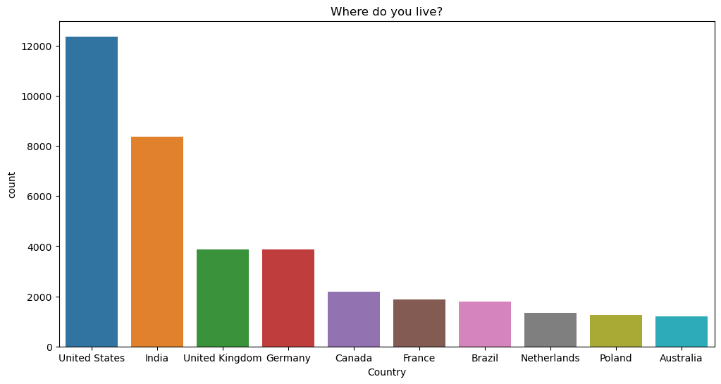

```python
plt.figure(figsize=(12,6))
#plt.xticks(rotation=75) If we have multiple countries to show o/p, at that time Name of country will overlap on one another so if we use this we won't
# get over lap on others.
plt.title(schema.Country)
sns.barplot(x = top_countries.index, y = top_countries, hue  = top_countries.index); # if you assign hue to the countries then the coluring
#will change from one country to another country.
plt.show()
```